# **Problem Statement**

```python
cluster_1
```

|  | index | CustomerID | Days_Since_Last_Purchase | Total_Transactions | Total_Products_Purchased | Total_Spend | Average_Transaction_Value | Unique_Products_Purchased | Average_Days_Between_Purchases | Day_Of_Week | Hour | Is_UK | Cancellation_Frequency | Cancellation_Rate | Monthly_Spending_Mean | Monthly_Spending_Std | Spending_Trend | Cluster |
| --- | --- | --- | --- | --- | --- | --- | --- | --- | --- | --- | --- | --- | --- | --- | --- | --- | --- | --- |
| 3 | 3 | 12350.0 | 310 | 1 | 197 | 334.4 | 334.4 | 17 | 0.0 | 2 | 16 | 0 | 0 | 0.0 | 334.4 | 0.0 | 0.0 | 1 |
| 7 | 7 | 12355.0 | 214 | 1 | 240 | 459.4 | 459.4 | 13 | 0.0 | 0 | 13 | 0 | 0 | 0.0 | 459.4 | 0.0 | 0.0 | 1 |
| 8 | 8 | 12358.0 | 1 | 2 | 248 | 1168.06 | 584.03 | 13 | 8.277778 | 1 | 10 | 0 | 0 | 0.0 | 584.03 | 140.247559 | 198.34 | 1 |
| 11 | 11 | 12363.0 | 109 | 2 | 408 | 552.0 | 276.0 | 23 | 6.045455 | 0 | 13 | 0 | 0 | 0.0 | 276.0 | 32.668333 | -46.2 | 1 |
| 13 | 13 | 12365.0 | 291 | 2 | 174 | 641.38 | 320.69 | 22 | 0.0 | 0 | 13 | 0 | 1 | 0.25 | 641.38 | 0.0 | 0.0 | 1 |
| ... | ... | ... | ... | ... | ... | ... | ... | ... | ... | ... | ... | ... | ... | ... | ... | ... | ... | ... |
| 4043 | 4043 | 18273.0 | 2 | 3 | 80 | 204.0 | 68.0 | 1 | 127.5 | 0 | 11 | 1 | 0 | 0.0 | 68.0 | 29.444864 | 0.0 | 1 |
| 4044 | 4044 | 18274.0 | 30 | 1 | 88 | 175.92 | 175.92 | 11 | 0.0 | 2 | 17 | 1 | 1 | 0.166667 | 175.92 | 0.0 | 0.0 | 1 |
| 4046 | 4046 | 18277.0 | 58 | 1 | 68 | 110.38 | 110.38 | 8 | 0.0 | 2 | 15 | 1 | 1 | 1.0 | 110.38 | 0.0 | 0.0 | 1 |
| 4047 | 4047 | 18278.0 | 73 | 1 | 66 | 173.9 | 173.9 | 9 | 0.0 | 1 | 11 | 1 | 0 | 0.0 | 173.9 | 0.0 | 0.0 | 1 |
| 4048 | 4048 | 18280.0 | 277 | 1 | 45 | 180.6 | 180.6 | 10 | 0.0 | 0 | 9 | 1 | 0 | 0.0 | 180.6 | 0.0 | 0.0 | 1 |

1642 rows × 18 columns

```python
cluster_1.describe().T
```

|  | count | mean | std | min | 25% | 50% | 75% | max |
| --- | --- | --- | --- | --- | --- | --- | --- | --- |
| index | 1642.0 | 2087.299026 | 1172.842286 | 3.0 | 1076.5 | 2122.5 | 3095.75 | 4048.0 |
| Days_Since_Last_Purchase | 1642.0 | 104.466504 | 103.006803 | 0.0 | 24.0 | 63.0 | 170.75 | 373.0 |
| Total_Transactions | 1642.0 | 2.369062 | 1.801947 | 1.0 | 1.0 | 2.0 | 3.0 | 13.0 |
| Total_Products_Purchased | 1642.0 | 385.552984 | 361.695612 | 2.0 | 135.0 | 265.0 | 519.0 | 3700.0 |
| Total_Spend | 1642.0 | 638.273539 | 511.582771 | 6.9 | 250.62 | 481.9 | 889.7575 | 3276.4 |
| Average_Transaction_Value | 1642.0 | 291.435458 | 187.394508 | 3.45 | 163.78225 | 247.408333 | 364.575 | 1706.88 |
| Unique_Products_Purchased | 1642.0 | 36.378197 | 33.090924 | 1.0 | 13.0 | 26.0 | 49.0 | 283.0 |
| Average_Days_Between_Purchases | 1642.0 | 3.985969 | 13.642366 | 0.0 | 0.0 | 0.915882 | 3.794118 | 309.0 |
| Day_Of_Week | 1642.0 | 1.0 | 0.825404 | 0.0 | 0.0 | 1.0 | 2.0 | 3.0 |
| Hour | 1642.0 | 12.354446 | 2.317792 | 7.0 | 11.0 | 12.0 | 14.0 | 18.0 |
| Is_UK | 1642.0 | 0.916565 | 0.276623 | 0.0 | 1.0 | 1.0 | 1.0 | 1.0 |
| Cancellation_Frequency | 1642.0 | 0.336784 | 0.656268 | 0.0 | 0.0 | 0.0 | 1.0 | 5.0 |
| Cancellation_Rate | 1642.0 | 0.179486 | 0.419795 | 0.0 | 0.0 | 0.0 | 0.071429 | 3.0 |
| Monthly_Spending_Mean | 1642.0 | 315.051851 | 202.495856 | 6.9 | 174.85625 | 279.26 | 393.56625 | 1706.88 |
| Monthly_Spending_Std | 1642.0 | 63.456931 | 100.181621 | 0.0 | 0.0 | 13.159257 | 94.684746 | 890.247438 |
| Spending_Trend | 1642.0 | -1.560389 | 133.601964 | -884.95 | -5.773 | 0.0 | 4.448 | 1259.0 |
| Cluster | 1642.0 | 1.0 | 0.0 | 1.0 | 1.0 | 1.0 | 1.0 | 1.0 |

```python
#RFM calculation cluster_1
r_quartile = cluster_1['Days_Since_Last_Purchase'].quantile(0.25)
f_quartile = cluster_1['Total_Transactions'].quantile(0.25)
m_quartile = cluster_1['Total_Spend'].quantile(0.25)

cluster_1['R_Score'] = cluster_1['Days_Since_Last_Purchase'].apply(lambda x: 4 if x <= r_quartile else 3 if x <= 2*r_quartile else 2 if x <= 3*r_quartile else 1)
cluster_1['F_Score'] = cluster_1['Total_Transactions'].apply(lambda x: 4 if x >= f_quartile else 3 if x >= 2*f_quartile else 2 if x >= 3*f_quartile else 1)
cluster_1['M_Score'] = cluster_1['Total_Spend'].apply(lambda x: 4 if x >= m_quartile else 3 if x >= 2*m_quartile else 2 if x >= 3*m_quartile else 1)
cluster_1['RFM_Segment'] =  cluster_1[['R_Score', 'F_Score', 'M_Score']].astype(str).apply(''.join, axis=1)

cluster_1['RFM_Segment']
```

```
3       144
7       144
8       444
11      144
13      144
       ...
4043    441
4044    341
4046    241
4047    141
4048    141
Name: RFM_Segment, Length: 1642, dtype: object
```

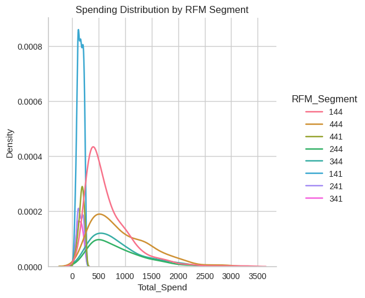

```python
sns.displot(cluster_1, x='Total_Spend', hue='RFM_Segment', kind='kde')
plt.title('Spending Distribution by RFM Segment')
plt.show()
```

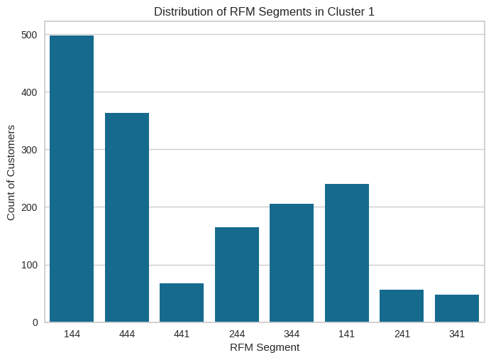

```python
#Most and least common RFM segments in cluster_1. Are there a few dominant segments or a more evenly distributed mix?
sns.countplot(x='RFM_Segment', data=cluster_1)
plt.title('Distribution of RFM Segments in Cluster 1')
plt.xlabel('RFM Segment')
plt.ylabel('Count of Customers')
plt.show()
```

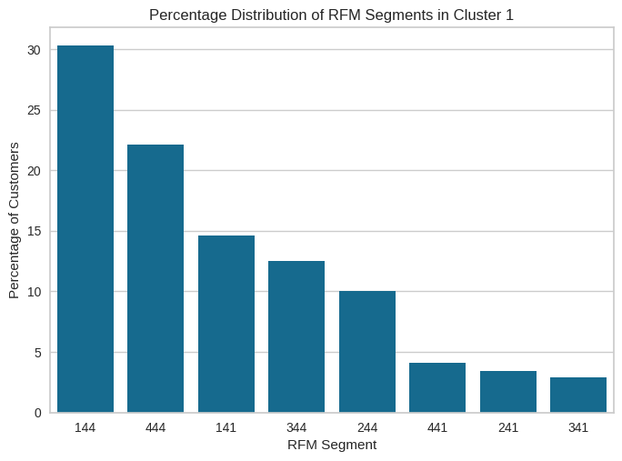

```python
# Proportion of each segment within the cluster, making it easier to see if one segment makes up the majority.
rfm_counts = cluster_1['RFM_Segment'].value_counts(normalize=True).sort_values(ascending=False) * 100
sns.barplot(x=rfm_counts.index, y=rfm_counts.values)
plt.title('Percentage Distribution of RFM Segments in Cluster 1')
plt.xlabel('RFM Segment')
plt.ylabel('Percentage of Customers')
plt.show()
```

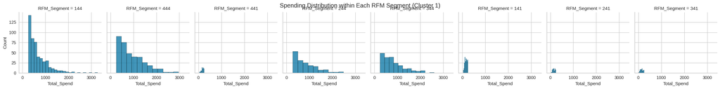

```python
#Spending behavior differs between RFM segments within cluster_1.
g = sns.FacetGrid(cluster_1, col='RFM_Segment', height=3)
g.map(sns.histplot, 'Total_Spend')
plt.suptitle('Spending Distribution within Each RFM Segment (Cluster 1)')
plt.show()
```

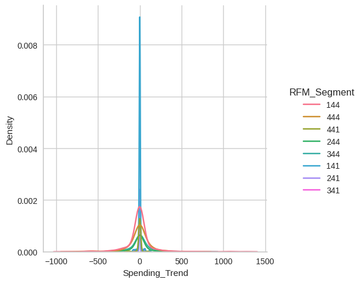

```python
# If you only have Spending_Trend
sns.displot(cluster_1, x='Spending_Trend', hue='RFM_Segment', kind='kde')
```

##### Find the Root Cause:

- Are they finding better deals with competitors?
- Do they want different products than what we offer?
- Are promotions not working like they used to? ##### Actions:
- Keep the High Spenders: Those who are still spending regularly. Special offers and loyalty programs could work here.
- Win Back Lost Customers: special promotions or personalized recommendations to get those who are spending less excited about shopping .
- Product Check: Which product categories are losing sales within Cluster_1. We need to fix issues with price, selection, or competitors in those areas specifically.

```python
cluster_2
```

|  | index | CustomerID | Days_Since_Last_Purchase | Total_Transactions | Total_Products_Purchased | Total_Spend | Average_Transaction_Value | Unique_Products_Purchased | Average_Days_Between_Purchases | Day_Of_Week | Hour | Is_UK | Cancellation_Frequency | Cancellation_Rate | Monthly_Spending_Mean | Monthly_Spending_Std | Spending_Trend | Cluster |
| --- | --- | --- | --- | --- | --- | --- | --- | --- | --- | --- | --- | --- | --- | --- | --- | --- | --- | --- |
| 1 | 1 | 12348.0 | 75 | 4 | 2341 | 1797.24 | 449.31 | 22 | 9.433333 | 3 | 19 | 0 | 0 | 0.0 | 449.31 | 301.159918 | -160.884 | 2 |
| 5 | 5 | 12353.0 | 204 | 1 | 20 | 89.0 | 89.0 | 4 | 0.0 | 3 | 17 | 0 | 0 | 0.0 | 89.0 | 0.0 | 0.0 | 2 |
| 6 | 6 | 12354.0 | 232 | 1 | 530 | 1079.4 | 1079.4 | 58 | 0.0 | 3 | 13 | 0 | 0 | 0.0 | 1079.4 | 0.0 | 0.0 | 2 |
| 10 | 10 | 12361.0 | 287 | 1 | 91 | 189.9 | 189.9 | 10 | 0.0 | 4 | 13 | 0 | 0 | 0.0 | 189.9 | 0.0 | 0.0 | 2 |
| 12 | 12 | 12364.0 | 7 | 4 | 1506 | 1313.1 | 328.275 | 70 | 1.25 | 4 | 15 | 0 | 0 | 0.0 | 328.275 | 223.846443 | -72.154 | 2 |
| ... | ... | ... | ... | ... | ... | ... | ... | ... | ... | ... | ... | ... | ... | ... | ... | ... | ... | ... |
| 4037 | 4037 | 18262.0 | 140 | 1 | 182 | 149.48 | 149.48 | 13 | 0.0 | 4 | 16 | 1 | 0 | 0.0 | 149.48 | 0.0 | 0.0 | 2 |
| 4038 | 4038 | 18263.0 | 25 | 3 | 1468 | 1213.16 | 404.386667 | 59 | 3.783333 | 3 | 10 | 1 | 1 | 0.05 | 404.386667 | 98.12637 | 47.08 | 2 |
| 4045 | 4045 | 18276.0 | 43 | 1 | 186 | 335.86 | 335.86 | 14 | 0.0 | 3 | 10 | 1 | 2 | 0.333333 | 335.86 | 0.0 | 0.0 | 2 |
| 4049 | 4049 | 18281.0 | 180 | 1 | 54 | 80.82 | 80.82 | 7 | 0.0 | 6 | 10 | 1 | 0 | 0.0 | 80.82 | 0.0 | 0.0 | 2 |
| 4050 | 4050 | 18282.0 | 7 | 2 | 103 | 178.05 | 89.025 | 12 | 10.818182 | 4 | 13 | 1 | 1 | 0.333333 | 89.025 | 15.817979 | -22.37 | 2 |

1657 rows × 18 columns

```python
cluster_2.describe().T
```

|  | count | mean | std | min | 25% | 50% | 75% | max |
| --- | --- | --- | --- | --- | --- | --- | --- | --- |
| index | 1657.0 | 2012.1207 | 1158.351154 | 1.0 | 992.0 | 1980.0 | 3004.0 | 4050.0 |
| Days_Since_Last_Purchase | 1657.0 | 107.532287 | 102.769824 | 0.0 | 25.0 | 65.0 | 176.0 | 372.0 |
| Total_Transactions | 1657.0 | 2.421847 | 1.817143 | 1.0 | 1.0 | 2.0 | 3.0 | 14.0 |
| Total_Products_Purchased | 1657.0 | 384.481593 | 361.374553 | 2.0 | 130.0 | 272.0 | 513.0 | 2341.0 |
| Total_Spend | 1657.0 | 649.758613 | 544.010874 | 6.2 | 252.1 | 475.37 | 899.69 | 3957.78 |
| Average_Transaction_Value | 1657.0 | 287.733219 | 191.203036 | 6.2 | 157.345 | 240.155 | 360.97 | 1743.15 |
| Unique_Products_Purchased | 1657.0 | 41.597465 | 40.118157 | 1.0 | 14.0 | 29.0 | 55.0 | 248.0 |
| Average_Days_Between_Purchases | 1657.0 | 2.859023 | 6.689192 | 0.0 | 0.0 | 0.652174 | 3.177419 | 126.0 |
| Day_Of_Week | 1657.0 | 4.182861 | 1.257248 | 3.0 | 3.0 | 4.0 | 6.0 | 6.0 |
| Hour | 1657.0 | 12.754979 | 2.380035 | 7.0 | 11.0 | 13.0 | 14.0 | 20.0 |
| Is_UK | 1657.0 | 0.922148 | 0.268019 | 0.0 | 1.0 | 1.0 | 1.0 | 1.0 |
| Cancellation_Frequency | 1657.0 | 0.299336 | 0.607685 | 0.0 | 0.0 | 0.0 | 0.0 | 4.0 |
| Cancellation_Rate | 1657.0 | 0.148157 | 0.376377 | 0.0 | 0.0 | 0.0 | 0.0 | 3.0 |
| Monthly_Spending_Mean | 1657.0 | 315.997134 | 209.955998 | 6.2 | 169.096667 | 271.05 | 393.49 | 1760.96 |
| Monthly_Spending_Std | 1657.0 | 65.030269 | 96.445282 | 0.0 | 0.0 | 14.043141 | 97.787883 | 621.054402 |
| Spending_Trend | 1657.0 | -9.935017 | 123.508928 | -867.41 | -12.653214 | 0.0 | 0.0 | 816.44 |
| Cluster | 1657.0 | 2.0 | 0.0 | 2.0 | 2.0 | 2.0 | 2.0 | 2.0 |

```python
#RFM calculation cluster_2
r_quartile = cluster_2['Days_Since_Last_Purchase'].quantile(0.25)
f_quartile = cluster_2['Total_Transactions'].quantile(0.25)
m_quartile = cluster_2['Total_Spend'].quantile(0.25)

cluster_2['R_Score'] = cluster_2['Days_Since_Last_Purchase'].apply(lambda x: 4 if x <= r_quartile else 3 if x <= 2*r_quartile else 2 if x <= 3*r_quartile else 1)
cluster_2['F_Score'] = cluster_2['Total_Transactions'].apply(lambda x: 4 if x >= f_quartile else 3 if x >= 2*f_quartile else 2 if x >= 3*f_quartile else 1)
cluster_2['M_Score'] = cluster_2['Total_Spend'].apply(lambda x: 4 if x >= m_quartile else 3 if x >= 2*m_quartile else 2 if x >= 3*m_quartile else 1)
cluster_2['RFM_Segment'] =  cluster_2[['R_Score', 'F_Score', 'M_Score']].astype(str).apply(''.join, axis=1)

cluster_2['RFM_Segment']
```

```
1       244
5       141
6       144
10      141
12      444
       ...
4037    141
4038    444
4045    344
4049    141
4050    441
Name: RFM_Segment, Length: 1657, dtype: object
```

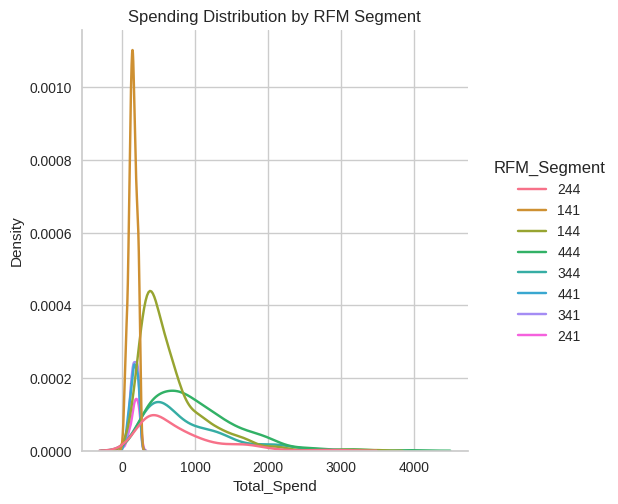

```python
sns.displot(cluster_2, x='Total_Spend', hue='RFM_Segment', kind='kde')
plt.title('Spending Distribution by RFM Segment')
plt.show()
```

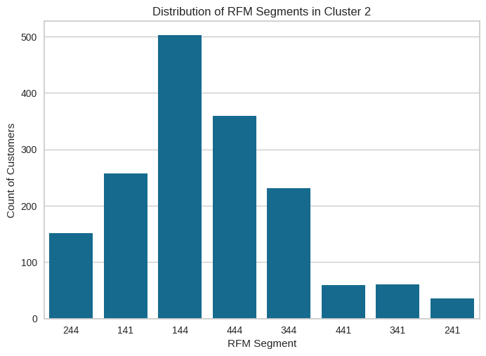

```python
#Most and least common RFM segments in cluster_2. Are there a few dominant segments or a more evenly distributed mix?
sns.countplot(x='RFM_Segment', data=cluster_2)
plt.title('Distribution of RFM Segments in Cluster 2')
plt.xlabel('RFM Segment')
plt.ylabel('Count of Customers')
plt.show()
```

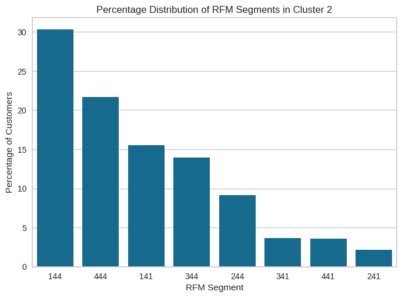

```python
# Proportion of each segment within the cluster_2, making it easier to see if one segment makes up the majority.
rfm_counts = cluster_2['RFM_Segment'].value_counts(normalize=True).sort_values(ascending=False) * 100
sns.barplot(x=rfm_counts.index, y=rfm_counts.values)
plt.title('Percentage Distribution of RFM Segments in Cluster 2')
plt.xlabel('RFM Segment')
plt.ylabel('Percentage of Customers')
plt.show()
```

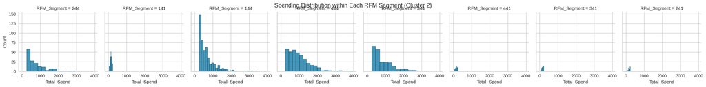

```python
#Spending behavior differs between RFM segments within cluster_2.
g = sns.FacetGrid(cluster_2, col='RFM_Segment', height=3)
g.map(sns.histplot, 'Total_Spend')
plt.suptitle('Spending Distribution within Each RFM Segment (Cluster 2)')
plt.show()
```

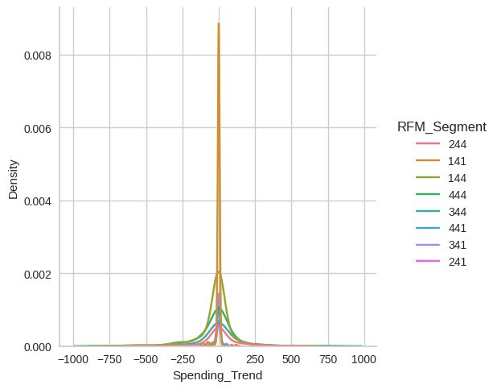

```python
#Spending_Trend
sns.displot(cluster_2, x='Spending_Trend', hue='RFM_Segment', kind='kde')
```

#### Recomendation System

```python
# Step 1: Extract the CustomerIDs of the outliers and remove their transactions from the main dataframe
outlier_customer_ids = outliers_data['CustomerID'].astype('float').unique()
df_filtered = df[~df['CustomerID'].isin(outlier_customer_ids)]
```

```python
# Step 2: Ensure consistent data type for CustomerID across both dataframes before merging
final_data['CustomerID'] = final_data['CustomerID'].astype('float')
```

```python
# Step 3: Merge the transaction data with the customer data to get the cluster information for each transaction
merged_data = df_filtered.merge(final_data[['CustomerID', 'Cluster']], on='CustomerID', how='inner')
merged_data
```

|  | InvoiceNo | StockCode | Description | Quantity | InvoiceDate | UnitPrice | CustomerID | Country | Transaction_Status | InvoiceDay | Total_Spend | Day_Of_Week | Hour | Year | Month | Cluster |
| --- | --- | --- | --- | --- | --- | --- | --- | --- | --- | --- | --- | --- | --- | --- | --- | --- |
| 0 | 536367 | 84879 | ASSORTED COLOUR BIRD ORNAMENT | 32 | 2010-12-01 08:34:00 | 1.69 | 13047.0 | United Kingdom | Completed | 2010-12-01 | 54.08 | 2 | 8 | 2010 | 12 | 0 |
| 1 | 536367 | 22745 | POPPY'S PLAYHOUSE BEDROOM | 6 | 2010-12-01 08:34:00 | 2.10 | 13047.0 | United Kingdom | Completed | 2010-12-01 | 12.60 | 2 | 8 | 2010 | 12 | 0 |
| 2 | 536367 | 22748 | POPPY'S PLAYHOUSE KITCHEN | 6 | 2010-12-01 08:34:00 | 2.10 | 13047.0 | United Kingdom | Completed | 2010-12-01 | 12.60 | 2 | 8 | 2010 | 12 | 0 |
| 3 | 536367 | 22749 | FELTCRAFT PRINCESS CHARLOTTE DOLL | 8 | 2010-12-01 08:34:00 | 3.75 | 13047.0 | United Kingdom | Completed | 2010-12-01 | 30.00 | 2 | 8 | 2010 | 12 | 0 |
| 4 | 536367 | 22310 | IVORY KNITTED MUG COSY | 6 | 2010-12-01 08:34:00 | 1.65 | 13047.0 | United Kingdom | Completed | 2010-12-01 | 9.90 | 2 | 8 | 2010 | 12 | 0 |
| ... | ... | ... | ... | ... | ... | ... | ... | ... | ... | ... | ... | ... | ... | ... | ... | ... |
| 294894 | 581578 | 22993 | SET OF 4 PANTRY JELLY MOULDS | 12 | 2011-12-09 12:16:00 | 1.25 | 12713.0 | Germany | Completed | 2011-12-09 | 15.00 | 4 | 12 | 2011 | 12 | 2 |
| 294895 | 581578 | 22907 | PACK OF 20 NAPKINS PANTRY DESIGN | 12 | 2011-12-09 12:16:00 | 0.85 | 12713.0 | Germany | Completed | 2011-12-09 | 10.20 | 4 | 12 | 2011 | 12 | 2 |
| 294896 | 581578 | 22908 | PACK OF 20 NAPKINS RED APPLES | 12 | 2011-12-09 12:16:00 | 0.85 | 12713.0 | Germany | Completed | 2011-12-09 | 10.20 | 4 | 12 | 2011 | 12 | 2 |
| 294897 | 581578 | 23215 | JINGLE BELL HEART ANTIQUE SILVER | 12 | 2011-12-09 12:16:00 | 2.08 | 12713.0 | Germany | Completed | 2011-12-09 | 24.96 | 4 | 12 | 2011 | 12 | 2 |
| 294898 | 581578 | 22736 | RIBBON REEL MAKING SNOWMEN | 10 | 2011-12-09 12:16:00 | 1.65 | 12713.0 | Germany | Completed | 2011-12-09 | 16.50 | 4 | 12 | 2011 | 12 | 2 |

294899 rows × 16 columns

```python
# Step 4: Identify the top 10 best-selling products in each cluster based on the total quantity sold
best_selling_products = merged_data.groupby(['Cluster', 'StockCode', 'Description'])['Quantity'].sum().reset_index()
best_selling_products = best_selling_products.sort_values(by=['Cluster', 'Quantity'], ascending=[True, False])
top_products_per_cluster = best_selling_products.groupby('Cluster').head(10)
```

```python
top_products_per_cluster
```

|  | Cluster | StockCode | Description | Quantity |
| --- | --- | --- | --- | --- |
| 2839 | 0 | 84077 | WORLD WAR 2 GLIDERS ASSTD DESIGNS | 13459 |
| 3217 | 0 | 85099B | JUMBO BAG RED RETROSPOT | 13091 |
| 3060 | 0 | 84879 | ASSORTED COLOUR BIRD ORNAMENT | 9989 |
| 1030 | 0 | 22178 | VICTORIAN GLASS HANGING T-LIGHT | 9206 |
| 29 | 0 | 16014 | SMALL CHINESE STYLE SCISSOR | 8137 |
| 3231 | 0 | 85123A | WHITE HANGING HEART T-LIGHT HOLDER | 8092 |
| 398 | 0 | 21212 | PACK OF 72 RETROSPOT CAKE CASES | 7972 |
| 1007 | 0 | 22151 | PLACE SETTING WHITE HEART | 6917 |
| 2925 | 0 | 84568 | GIRLS ALPHABET IRON ON PATCHES | 6720 |
| 874 | 0 | 21977 | PACK OF 60 PINK PAISLEY CAKE CASES | 5982 |
| 6507 | 1 | 84879 | ASSORTED COLOUR BIRD ORNAMENT | 5463 |
| 6294 | 1 | 84077 | WORLD WAR 2 GLIDERS ASSTD DESIGNS | 4572 |
| 6672 | 1 | 85123A | WHITE HANGING HEART T-LIGHT HOLDER | 4526 |
| 3558 | 1 | 16014 | SMALL CHINESE STYLE SCISSOR | 3643 |
| 3593 | 1 | 17003 | BROCADE RING PURSE | 3603 |
| 3920 | 1 | 21212 | PACK OF 72 RETROSPOT CAKE CASES | 3537 |
| 3541 | 1 | 15036 | ASSORTED COLOURS SILK FAN | 3528 |
| 6659 | 1 | 85099B | JUMBO BAG RED RETROSPOT | 2762 |
| 4918 | 1 | 22577 | WOODEN HEART CHRISTMAS SCANDINAVIAN | 2520 |
| 4099 | 1 | 21498 | RED RETROSPOT WRAP | 2510 |
| 9743 | 2 | 84077 | WORLD WAR 2 GLIDERS ASSTD DESIGNS | 6040 |
| 9958 | 2 | 84879 | ASSORTED COLOUR BIRD ORNAMENT | 4926 |
| 6975 | 2 | 15036 | ASSORTED COLOURS SILK FAN | 4280 |
| 10126 | 2 | 85123A | WHITE HANGING HEART T-LIGHT HOLDER | 4190 |
| 6995 | 2 | 16045 | POPART WOODEN PENCILS ASST | 3100 |
| 10111 | 2 | 85099B | JUMBO BAG RED RETROSPOT | 3087 |
| 7418 | 2 | 21326 | AGED GLASS SILVER T-LIGHT HOLDER | 2916 |
| 8271 | 2 | 22492 | MINI PAINT SET VINTAGE | 2916 |
| 7982 | 2 | 22178 | VICTORIAN GLASS HANGING T-LIGHT | 2784 |
| 7349 | 2 | 21212 | PACK OF 72 RETROSPOT CAKE CASES | 2736 |

```python
# Step 5: Create a record of products purchased by each customer in each cluster
customer_purchases = merged_data.groupby(['CustomerID', 'Cluster', 'StockCode'])['Quantity'].sum().reset_index()
```

```python
customer_purchases
```

|  | CustomerID | Cluster | StockCode | Quantity |
| --- | --- | --- | --- | --- |
| 0 | 12347.0 | 0 | 16008 | 24 |
| 1 | 12347.0 | 0 | 17021 | 36 |
| 2 | 12347.0 | 0 | 20665 | 6 |
| 3 | 12347.0 | 0 | 20719 | 40 |
| 4 | 12347.0 | 0 | 20780 | 12 |
| ... | ... | ... | ... | ... |
| 224400 | 18287.0 | 0 | 84920 | 4 |
| 224401 | 18287.0 | 0 | 85039A | 96 |
| 224402 | 18287.0 | 0 | 85039B | 120 |
| 224403 | 18287.0 | 0 | 85040A | 48 |
| 224404 | 18287.0 | 0 | 85173 | 48 |

224405 rows × 4 columns

```python
# Step 6: Generate recommendations for each customer in each cluster
recommendations = []
for cluster in top_products_per_cluster['Cluster'].unique():
    top_products = top_products_per_cluster[top_products_per_cluster['Cluster'] == cluster]
    customers_in_cluster = final_data[final_data['Cluster'] == cluster]['CustomerID']

    for customer in customers_in_cluster:
        # Identify products already purchased by the customer
        customer_purchased_products = customer_purchases[(customer_purchases['CustomerID'] == customer) &
                                                         (customer_purchases['Cluster'] == cluster)]['StockCode'].tolist()

        # Find top 3 products in the best-selling list that the customer hasn't purchased yet
        top_products_not_purchased = top_products[~top_products['StockCode'].isin(customer_purchased_products)]
        top_3_products_not_purchased = top_products_not_purchased.head(3)

        # Append the recommendations to the list
        recommendations.append([customer, cluster] + top_3_products_not_purchased[['StockCode', 'Description']].values.flatten().tolist())

# Step 7: Create a dataframe from the recommendations list and merge it with the original customer data
recommendations_df = pd.DataFrame(recommendations, columns=['CustomerID', 'Cluster', 'Rec1_StockCode', 'Rec1_Description', \
                                                 'Rec2_StockCode', 'Rec2_Description', 'Rec3_StockCode', 'Rec3_Description'])
customer_data_with_recommendations = final_data.merge(recommendations_df, on=['CustomerID', 'Cluster'], how='right')
```

```python
customer_data_with_recommendations
```

|  | index | CustomerID | Days_Since_Last_Purchase | Total_Transactions | Total_Products_Purchased | Total_Spend | Average_Transaction_Value | Unique_Products_Purchased | Average_Days_Between_Purchases | Day_Of_Week | ... | Monthly_Spending_Mean | Monthly_Spending_Std | Spending_Trend | Cluster | Rec1_StockCode | Rec1_Description | Rec2_StockCode | Rec2_Description | Rec3_StockCode | Rec3_Description |
| --- | --- | --- | --- | --- | --- | --- | --- | --- | --- | --- | --- | --- | --- | --- | --- | --- | --- | --- | --- | --- | --- |
| 0 | 0 | 12347.0 | 2 | 7 | 2458 | 4310.0 | 615.714286 | 103 | 2.016575 | 1 | ... | 615.714286 | 341.070789 | 4.486071 | 0 | 84077 | WORLD WAR 2 GLIDERS ASSTD DESIGNS | 85099B | JUMBO BAG RED RETROSPOT | 84879 | ASSORTED COLOUR BIRD ORNAMENT |
| 1 | 2 | 12349.0 | 18 | 1 | 631 | 1757.55 | 1757.55 | 73 | 0.0 | 0 | ... | 1757.55 | 0.0 | 0.0 | 0 | 84077 | WORLD WAR 2 GLIDERS ASSTD DESIGNS | 85099B | JUMBO BAG RED RETROSPOT | 84879 | ASSORTED COLOUR BIRD ORNAMENT |
| 2 | 4 | 12352.0 | 36 | 8 | 536 | 2506.04 | 313.255 | 59 | 3.095238 | 1 | ... | 626.51 | 453.171921 | -58.712 | 0 | 84077 | WORLD WAR 2 GLIDERS ASSTD DESIGNS | 85099B | JUMBO BAG RED RETROSPOT | 84879 | ASSORTED COLOUR BIRD ORNAMENT |
| 3 | 9 | 12360.0 | 52 | 3 | 1165 | 2662.06 | 887.353333 | 105 | 1.15625 | 1 | ... | 887.353333 | 306.054391 | -19.9 | 0 | 84077 | WORLD WAR 2 GLIDERS ASSTD DESIGNS | 85099B | JUMBO BAG RED RETROSPOT | 84879 | ASSORTED COLOUR BIRD ORNAMENT |
| 4 | 15 | 12370.0 | 51 | 4 | 2352 | 3541.94 | 885.485 | 143 | 1.872727 | 1 | ... | 1180.646667 | 600.34727 | -562.495 | 0 | 84077 | WORLD WAR 2 GLIDERS ASSTD DESIGNS | 85099B | JUMBO BAG RED RETROSPOT | 22178 | VICTORIAN GLASS HANGING T-LIGHT |
| ... | ... | ... | ... | ... | ... | ... | ... | ... | ... | ... | ... | ... | ... | ... | ... | ... | ... | ... | ... | ... | ... |
| 4048 | 4037 | 18262.0 | 140 | 1 | 182 | 149.48 | 149.48 | 13 | 0.0 | 4 | ... | 149.48 | 0.0 | 0.0 | 2 | 84077 | WORLD WAR 2 GLIDERS ASSTD DESIGNS | 84879 | ASSORTED COLOUR BIRD ORNAMENT | 15036 | ASSORTED COLOURS SILK FAN |
| 4049 | 4038 | 18263.0 | 25 | 3 | 1468 | 1213.16 | 404.386667 | 59 | 3.783333 | 3 | ... | 404.386667 | 98.12637 | 47.08 | 2 | 84077 | WORLD WAR 2 GLIDERS ASSTD DESIGNS | 84879 | ASSORTED COLOUR BIRD ORNAMENT | 15036 | ASSORTED COLOURS SILK FAN |
| 4050 | 4045 | 18276.0 | 43 | 1 | 186 | 335.86 | 335.86 | 14 | 0.0 | 3 | ... | 335.86 | 0.0 | 0.0 | 2 | 84077 | WORLD WAR 2 GLIDERS ASSTD DESIGNS | 84879 | ASSORTED COLOUR BIRD ORNAMENT | 15036 | ASSORTED COLOURS SILK FAN |
| 4051 | 4049 | 18281.0 | 180 | 1 | 54 | 80.82 | 80.82 | 7 | 0.0 | 6 | ... | 80.82 | 0.0 | 0.0 | 2 | 84077 | WORLD WAR 2 GLIDERS ASSTD DESIGNS | 84879 | ASSORTED COLOUR BIRD ORNAMENT | 15036 | ASSORTED COLOURS SILK FAN |
| 4052 | 4050 | 18282.0 | 7 | 2 | 103 | 178.05 | 89.025 | 12 | 10.818182 | 4 | ... | 89.025 | 15.817979 | -22.37 | 2 | 84077 | WORLD WAR 2 GLIDERS ASSTD DESIGNS | 84879 | ASSORTED COLOUR BIRD ORNAMENT | 15036 | ASSORTED COLOURS SILK FAN |

4053 rows × 24 columns